# Reproducible Research: Peer Assessment 1

## Loading dependant packages

```r
library(dplyr)
```

```r
library(ggplot2)
library(stats)
library(lattice)
library(Hmisc)
library(scales)
```

## Setting up present working directory

```r
setwd("C:/Users/hp/datasciencecoursera/Course5(Reproducible Research)/Week 2")
```

## Loading and preprocessing the data

### 1. Load the data (i.e. read.csv())

```r
if (!file.exists("activity.zip"))
{
        download.file("https://d396qusza40orc.cloudfront.net/repdata%2Fdata%2Factivity.zip")
}

if(!file.exists("activity.csv")){
        files <- unzip("activity.zip")
}

df <- read.csv('activity.csv', sep = ',', header = TRUE, na.strings = NA, stringsAsFactors = FALSE)
df1 <- tbl_df(df)
```

### 2. Process/transform the data (if necessary) into a format suitable for your analysis

```r
#df$interval <- strptime(gsub("([0-9]{1,2})([0-9]{2})", "\\1:\\2", activityData$interval), format='%H:%M')
```

### What is total number of steps taken per day?

```r
totalstepsbydate <- df1 %>% select(date, steps) %>% group_by(date) %>% summarise_if(is.numeric,sum,na.rm = TRUE)%>%ungroup()

aggregatedTotalStepsByDay <- aggregate(steps~date, df, FUN=sum, na.rm=TRUE, na.action=na.pass)
```

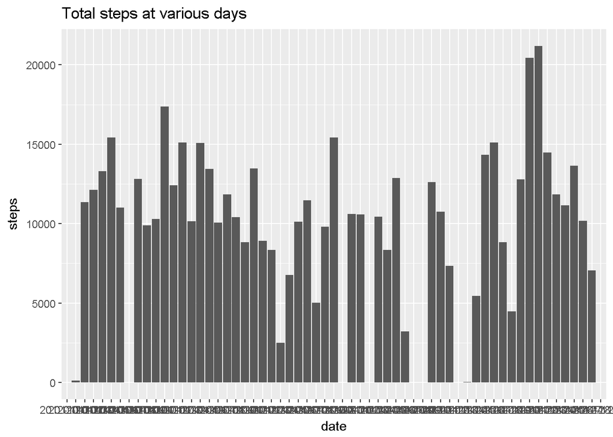

```r
# Using ggplot2
g <- ggplot(totalstepsbydate, aes(x = date))
g + geom_bar(aes(weight = steps), stat = "count") + ylab("steps") + xlab("date") + ggtitle('Total steps at various days')
```

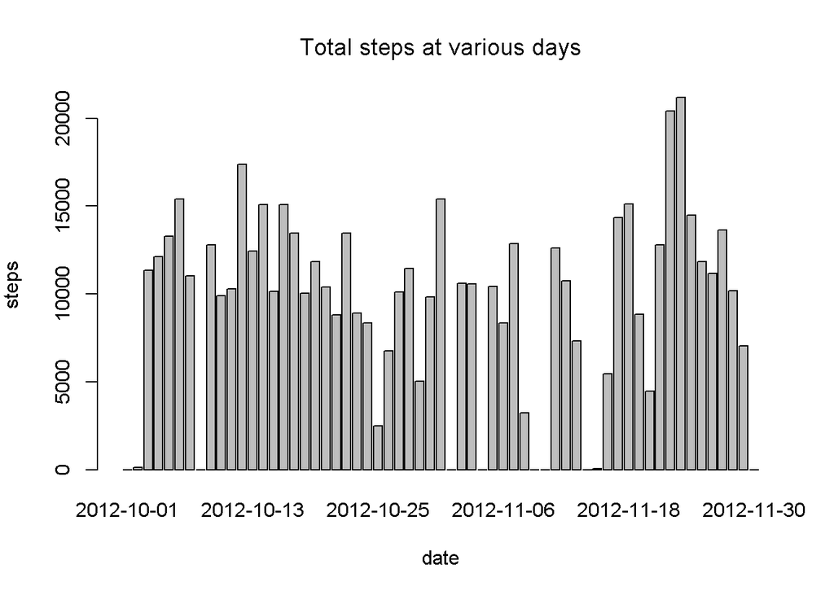

```r
# Using base Plot
barplot(height=aggregatedTotalStepsByDay$steps, names.arg=aggregatedTotalStepsByDay$date, xlab="date", ylab=expression('steps'),main=expression('Total steps at various days'))
```

### 2. Calculate and report the mean and median total number of steps taken per day

```r
meanstepsbydate <- df1 %>% select(date, steps) %>% group_by(date) %>% summarise_if(is.numeric,mean,na.rm = TRUE)%>%ungroup()
medianstepsbydate <- df1 %>% select(date, steps) %>% group_by(date) %>% summarise_if(is.numeric,median,na.rm = TRUE)%>%ungroup()
stepsByDayMean <- mean(totalstepsbydate$steps)
stepsByDayMedian <- median(totalstepsbydate$steps)
print(paste0("Mean Steps by day is: ", stepsByDayMean))
```

```
## [1] "Mean Steps by day is: 9354.22950819672"
```

```r
cat("Median Steps by day is: ", stepsByDayMedian)
```

```
## Median Steps by day is:  10395
```

## What is the average daily activity pattern?

```r
average_daily_activity_pattern <- df1 %>% select(steps, interval) %>% group_by(interval) %>% summarise_if(is.numeric,mean,na.rm = TRUE)%>%ungroup()
```

### 1. Make a time series plot

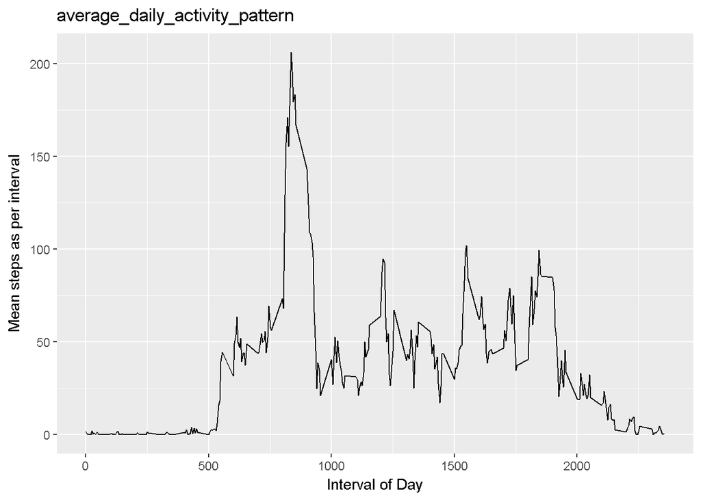

```r
## ggplot2
g <- ggplot(average_daily_activity_pattern, aes(x = interval, y = steps))
g + geom_line() + xlab("Interval of Day") + ylab("Mean steps as per interval") + ggtitle("average_daily_activity_pattern")
```

### 2. Which 5-minute interval, on average across all the days in the dataset, contains the maximum number of steps?

```r
moststeps <- which.max(average_daily_activity_pattern$steps)
timeWhenmoststeps <- paste(as.character(as.integer(average_daily_activity_pattern[moststeps,'interval']/60)), as.character(average_daily_activity_pattern[moststeps,'interval'] %% 60), sep = ":")
cat("time when max no. of Steps by day is: ", timeWhenmoststeps)
```

[output not shown]

## Imputing missing values

### 1. Calculate and report the total number of missing values in the dataset

```r
numMissingValues <- length(which(is.na(df1$steps)))
cat("number of missing values in Steps by day is: ", numMissingValues)
```

```
## number of missing values in Steps by day is:  2304
```

### 2. Devise a strategy for filling in all of the missing values in the dataset.

To fill NAs we will take the mean of total dataset and put it to replace the NAs

### 3. Create a new dataset that is equal to the original dataset but with the missing data filled in.

```r
df1Imputed <- df1
df1Imputed$steps <- impute(df1$steps, fun=mean)

dfImputed <- df
dfImputed$steps <- impute(df$steps, fun=mean)
```

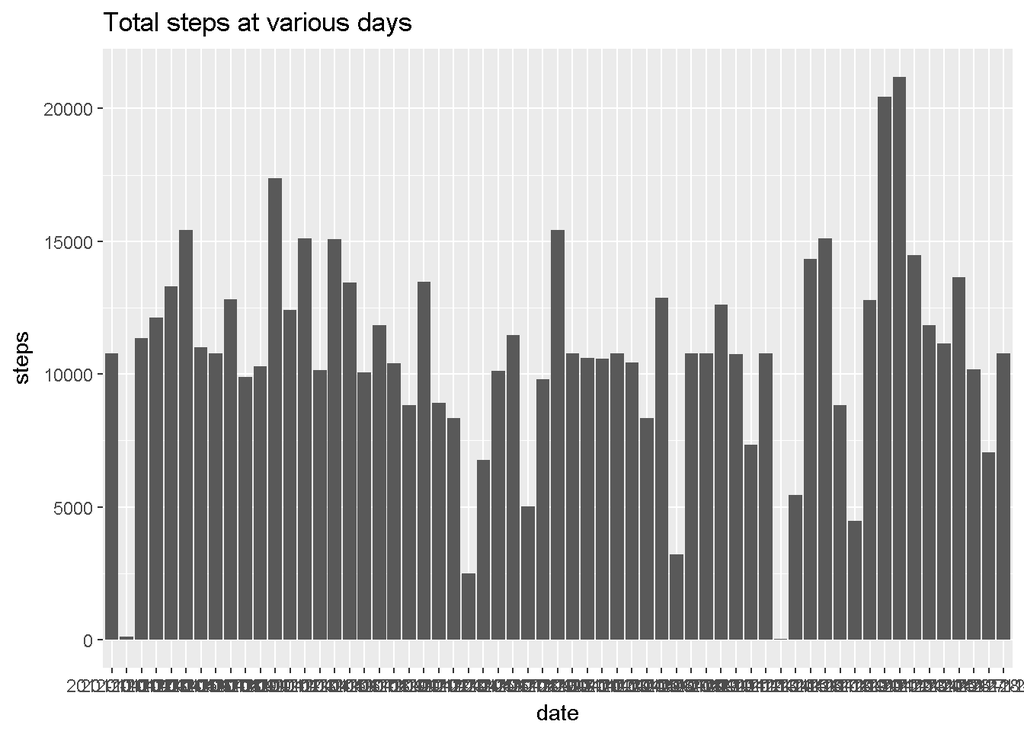

```r
totalstepsbydateImputed <- df1Imputed %>% select(date, steps) %>% group_by(date) %>% summarise_if(is.numeric,sum,na.rm = TRUE)%>%ungroup()

aggregatedTotalStepsByDayImputed <- aggregate(steps~date, dfImputed, FUN=sum, na.rm=TRUE, na.action=na.pass)

## ggplot2
g <- ggplot(totalstepsbydateImputed, aes(x = date))
g + geom_bar(aes(weight = steps), stat = "count") + ylab("steps") + xlab("date") + ggtitle('Total steps at various days')
```

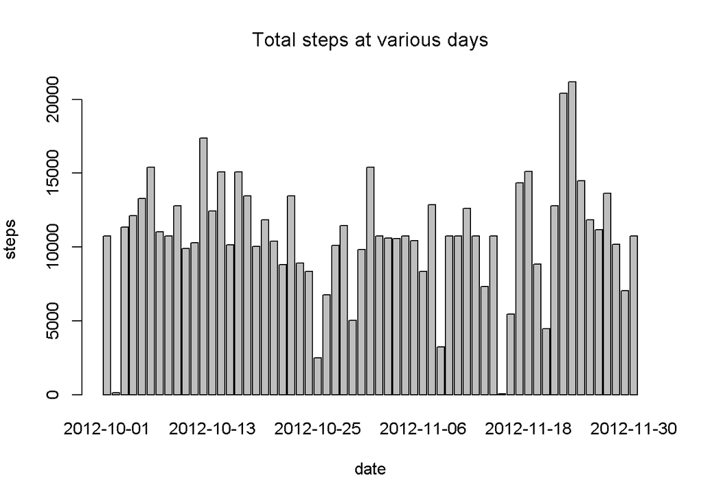

```r
# using base plot system
barplot(height=aggregatedTotalStepsByDayImputed$steps, names.arg=aggregatedTotalStepsByDayImputed$date, xlab="date", ylab=expression('steps'),main=expression('Total steps at various days'))
```

### … and Calculate and report the mean and median total number of steps taken per day.

```r
meanstepsbydateImputed <- df1Imputed %>% select(date, steps) %>% group_by(date) %>% summarise_if(is.numeric,mean,na.rm = TRUE)%>%ungroup()
medianstepsbydateImputed <- df1Imputed %>% select(date, steps) %>% group_by(date) %>% summarise_if(is.numeric,median,na.rm = TRUE)%>%ungroup()
stepsByDayMeanImputed <- mean(totalstepsbydateImputed$steps)
stepsByDayMedianImputed <- median(totalstepsbydateImputed$steps)
cat("Mean of imputed Steps by day is: ", stepsByDayMeanImputed)
```

```
## Mean of imputed Steps by day is:  10766.19
```

```r
cat("Median of imputed Steps by day is: ", stepsByDayMedianImputed)
```

```
## Median of imputed Steps by day is:  10766.19
```

## Are there differences in activity patterns between weekdays and weekends?

### 1. Create a new factor variable in the dataset with two levels - “weekday” and “weekend” indicating whether a given date is a weekday or weekend day.

```r
df1Imputed$dayType <-  ifelse(as.POSIXlt(df1Imputed$date)$wday %in% c(0,6), 'weekend', 'weekday')
```

### 2. Make a panel plot containing a time series plot

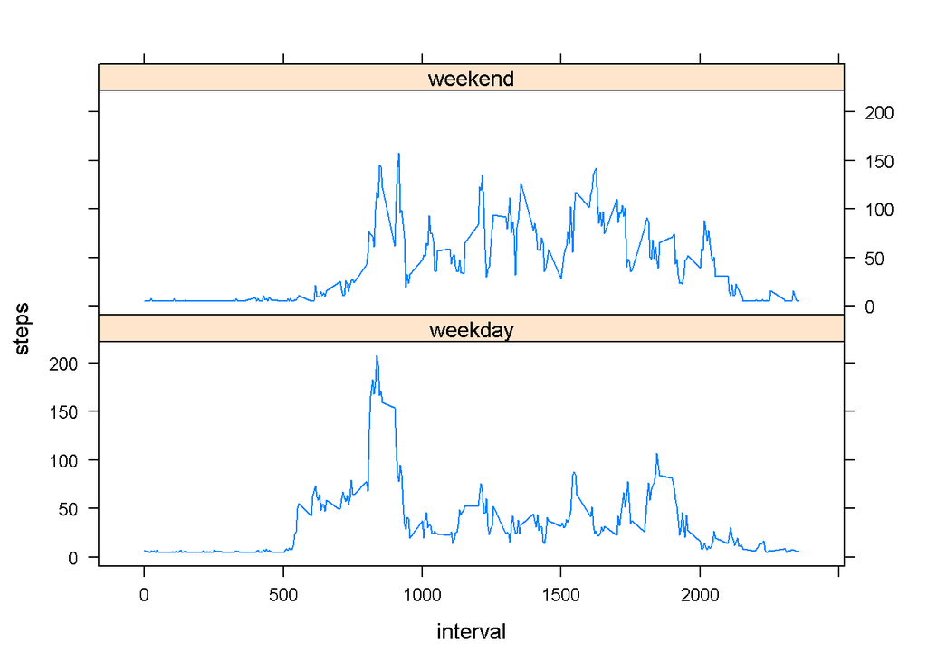

```r
aggregatedDataImputed <- df1Imputed %>% group_by(dayType,interval) %>% summarise_if(is.numeric,mean,na.rm = TRUE)%>%ungroup()

# using lattice plot
xyplot(steps ~ interval | dayType,
       data = aggregatedDataImputed,
       layout = c(1, 2),
       type = "l")
```

```r
if(FALSE){
# using ggplot2
ggplot(aggregatedDataImputed, aes(interval, steps)) +
        geom_line(col = "blue") +
        facet_grid(dayType ~ .) +
        xlab("Interval") +
        ylab("Number of steps") +
        ggtitle(" ")+
        theme(panel.background = element_rect(fill = "white"),
              strip.background = element_rect(colour = "black",
                                              fill = "antiquewhite1"),
        axis.line = element_line(colour = "black"))}
```